# **Semistructured Merge on Industry**

- [RAW Results and Logs](https://github.com/spgroup/conflict-patterns/tree/master/isi/results-log-raw.zip)

## How often conflicts occur with semistructured and unstructured merge?

There is a difference of **50.23%** in the number of reported conflicts.

|  | Semistructured Merge | Unstructured Merge |
| --- | --- | --- |
| 1 | 432 | 649 |

Merge scenarios had at least one conflict with *semistructured* merge on average **11.84%** of the considered merge scenarios, with a standard deviation of **25.13%** . Considering aggregated numbers of all projects of our sample, this corresponds to **5.56%** of the considered merge scenarios. Besides that, merge scenarios had at least one conflict with *unstructured* merge on average **15.14%** of the considered merge scenarios, with a standard deviation of **25.54%** . Considering aggregated numbers of all projects of our sample, this corresponds to **7.99%** of the considered merge scenarios.

|  | Project | Merge Scenarios | Conflicting Semistructured Merge Scenarios | Conflicting Unstructured Merge Scenarios |
| --- | --- | --- | --- | --- |
| 1 | RDIProject4 | 3 | - | - |
| 2 | RDIProject3 | 450 | 17 | 29 |
| 3 | RDIProject2 | 6 | 1 | 2 |
| 4 | RDIProject1 | 12 | 1 | 1 |
| 5 | RDIProject9 | 1 | 1 | 1 |
| 6 | RDIProject8 | 11 | - | - |
| 7 | RDIProject7 | 20 | 1 | 4 |
| 8 | RDUProject2 | 121 | 18 | 22 |
| 9 | RDIProject6 | 493 | 16 | 21 |
| 10 | RDUProject3 | 171 | 29 | 37 |

[output cut: 8 more lines]

## How long does take semistructured and unstructured merge?

|  | Semistructured Merge | Unstructured Merge |
| --- | --- | --- |
| 1 | 152.8 | 28.7 |

## How often semistructured and unstructured merge differ?

### By All Scenarios

The tools differ on average **3.56%** of the considered merge scenarios, with a standard deviation of **5.89%** . Considering aggregated numbers of all projects of our sample, this corresponds to **2.83%** of the considered merge scenarios.

|  | Project | Merge Scenarios | Conflicting Merge Scenarios Only With Semistructured Merge | Conflicting Merge Scenarios Only With Unstructured Merge | % |
| --- | --- | --- | --- | --- | --- |
| 1 | RDIProject4 | 3 | - | - | 0 |
| 2 | RDIProject3 | 450 | - | 12 | 2.67 |
| 3 | RDIProject2 | 6 | - | 1 | 16.67 |
| 4 | RDIProject1 | 12 | - | - | 0 |
| 5 | RDIProject9 | 1 | - | - | 0 |
| 6 | RDIProject8 | 11 | - | - | 0 |
| 7 | RDIProject7 | 20 | - | 3 | 15 |
| 8 | RDUProject2 | 121 | - | 4 | 3.31 |
| 9 | RDIProject6 | 493 | 1 | 6 | 1.42 |
| 10 | RDUProject3 | 171 | 3 | 11 | 8.18 |

[output cut: 8 more lines]

### By Conflicting Scenarios

The tools differ on average **32.41%** of the considered merge scenarios, with a standard deviation of **25.79%** . Considering aggregated numbers of all projects of our sample, this corresponds to **34.57%** of the considered merge scenarios.

|  | Project | Conflicting Merge Scenarios | Conflicting Merge Scenarios Only With Semistructured Merge | Conflicting Merge Scenarios Only With Unstructured Merge | % |
| --- | --- | --- | --- | --- | --- |
| 1 | RDIProject4 | - | - | - | 0 |
| 2 | RDIProject3 | 29 | - | 12 | 41.38 |
| 3 | RDIProject2 | 2 | - | 1 | 50 |
| 4 | RDIProject1 | 1 | - | - | 0 |
| 5 | RDIProject9 | 1 | - | - | 0 |
| 6 | RDIProject8 | - | - | - | 0 |
| 7 | RDIProject7 | 4 | - | 3 | 75 |
| 8 | RDUProject2 | 22 | - | 4 | 18.18 |
| 9 | RDIProject6 | 22 | 1 | 6 | 31.82 |
| 10 | RDUProject3 | 40 | 3 | 11 | 35 |

[output cut: 8 more lines]

### Boxplot

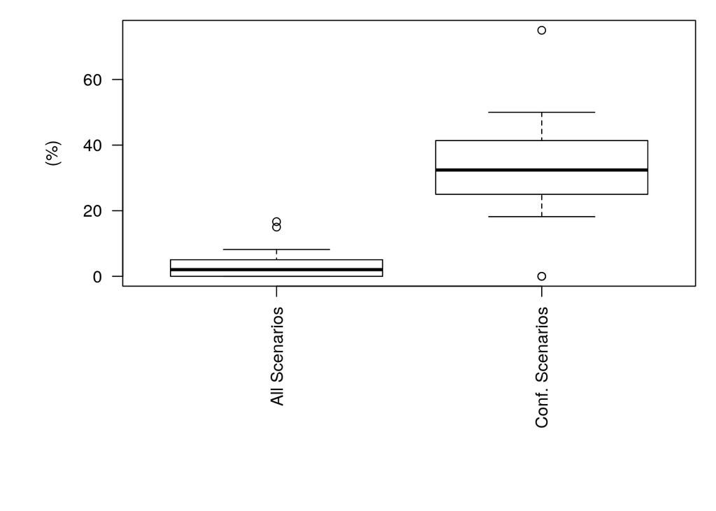

## When compared to semistructured merge, does unstructured merge reduce unnecessary integration effort by reporting fewer false positives?

### Semistructured Merge Additional False Positives

#### By All Scenarios

On average **2.23%** of the considered merge scenarios, had semistructured merge additional falses positives, with a standard deviation of **4.43%** . Considering aggregated numbers of all projects of our sample, this corresponds to **1.37%** of the considered merge scenarios.

|  | Project | Merge Scenarios | Merge Scenarios with Renaming Conflicts | Merge Scenarios with Deletion Conflicts | % |
| --- | --- | --- | --- | --- | --- |
| 1 | RDIProject4 | 3 | - | - | 0 |
| 2 | RDIProject3 | 450 | 4 | - | 0.89 |
| 3 | RDIProject2 | 6 | 1 | - | 16.67 |
| 4 | RDIProject1 | 12 | - | - | 0 |
| 5 | RDIProject9 | 1 | - | - | 0 |
| 6 | RDIProject8 | 11 | - | - | 0 |
| 7 | RDIProject7 | 20 | 1 | - | 5 |
| 8 | RDUProject2 | 121 | 4 | - | 3.31 |
| 9 | RDIProject6 | 493 | 4 | - | 0.81 |
| 10 | RDUProject3 | 171 | 10 | - | 5.85 |

[output cut: 8 more lines]

#### By Conflicts

On average **39.93%** of the number of semistructured merge reported conflicts are additional falses positives, with a standard deviation of **36.51%** . Considering aggregated numbers of all projects of our sample, this corresponds to **27.08%** of the number of semistructured merge reported conflicts.

|  | Project | Conflicts | Renaming Conflicts | Deletion Conflicts | % |
| --- | --- | --- | --- | --- | --- |
| 1 | RDIProject4 | - | - | - | 0 |
| 2 | RDIProject3 | 29 | 12 | - | 41.38 |
| 3 | RDIProject2 | 1 | 1 | - | 100 |
| 4 | RDIProject1 | 2 | - | - | 0 |
| 5 | RDIProject9 | 1 | - | - | 0 |
| 6 | RDIProject8 | - | - | - | 0 |
| 7 | RDIProject7 | 3 | 3 | - | 100 |
| 8 | RDUProject2 | 50 | 19 | - | 38 |
| 9 | RDIProject6 | 125 | 20 | - | 16 |
| 10 | RDUProject3 | 145 | 31 | - | 21.38 |

[output cut: 8 more lines]

### Unstructured Merge Additional False Positives

#### By All Scenarios

On average **13.33%** of the considered merge scenarios, had unstructured merge additional falses positives, with a standard deviation of **25.88%** . Considering aggregated numbers of all projects of our sample, this corresponds to **5.51%** of the considered merge scenarios.

|  | Project | Merge Scenarios | Merge Scenarios with Unstructured Merge Additional False Positives * | % |
| --- | --- | --- | --- | --- |
| 1 | RDIProject4 | 3 | - | 0 |
| 2 | RDIProject3 | 450 | 19 | 4.22 |
| 3 | RDIProject2 | 6 | 2 | 33.33 |
| 4 | RDIProject1 | 12 | - | 0 |
| 5 | RDIProject9 | 1 | 1 | 100 |
| 6 | RDIProject8 | 11 | - | 0 |
| 7 | RDIProject7 | 20 | 4 | 20 |
| 8 | RDUProject2 | 121 | 15 | 12.4 |
| 9 | RDIProject6 | 493 | 12 | 2.43 |
| 10 | RDUProject3 | 171 | 28 | 16.37 |

[output cut: 8 more lines]

#### By Conflicts

On average **48.36%** of the number of unstructured merge reported conflicts are additional falses positives, with a standard deviation of **23.76%** . Considering aggregated numbers of all projects of our sample, this corresponds to **45.76%** of the number of unstructured merge reported conflicts.

|  | Project | Conflicts | Ordering Conflicts | % |
| --- | --- | --- | --- | --- |
| 1 | RDIProject4 | - | - | 0 |
| 2 | RDIProject3 | 53 | 27 | 50.94 |
| 3 | RDIProject2 | 4 | 3 | 75 |
| 4 | RDIProject1 | 2 | - | 0 |
| 5 | RDIProject9 | 2 | 1 | 50 |
| 6 | RDIProject8 | - | - | 0 |
| 7 | RDIProject7 | 13 | 11 | 84.62 |
| 8 | RDUProject2 | 116 | 69 | 59.48 |
| 9 | RDIProject6 | 149 | 42 | 28.19 |
| 10 | RDUProject3 | 182 | 84 | 46.15 |

[output cut: 8 more lines]

Statistical significance **by scenarios**, consider a confidence level of 0.95 (p-value = 0.05):

```
##
##  Wilcoxon signed rank test with continuity correction
##
## data:  aFP_ST$unstructured and aFP_SS$Semistructured
## V = 45, p-value = 0.009152
## alternative hypothesis: true location shift is not equal to 0
```

Strength/magnitude of the statistical claim (*effect size*) **by scenarios**:

```
##
## Cliff's Delta
##
## delta estimate: 0.2622222 (small)
## 95 percent confidence interval:
##      lower      upper
## -0.1628183  0.6051713
```

Statistical significance **by conflicts**, consider a confidence level of 0.95 (p-value = 0.05):

```
##
##  Wilcoxon signed rank test with continuity correction
##
## data:  aFP_ST$unstructured and aFP_SS$Semistructured
## V = 30, p-value = 0.4069
## alternative hypothesis: true location shift is not equal to 0
```

Strength/magnitude of the statistical claim (*effect size*) **by conflicts**:

```
##
## Cliff's Delta
##
## delta estimate: 0.26 (small)
## 95 percent confidence interval:
##      lower      upper
## -0.1267928  0.5781609
```

## When compared to semistructured merge, does unstructured merge compromise integration correctness by having more false negatives?

### Semistructured Merge Additional False Negatives

#### By All Scenarios

On average **3.39%** of the considered merge scenarios, had semistructured merge additional falses negatives, with a standard deviation of **5.79%** . Considering aggregated numbers of all projects of our sample, this corresponds to **2.88%** of the considered merge scenarios.

|  | Project | Merge Scenarios | Merge Scenarios with Type Ambiguity Errors | Merge Scenarios with References between New and Edited Elements | Merge Scenarios with Initialization Blocks | Merge Scenarios with Acidental Conflicts | % |
| --- | --- | --- | --- | --- | --- | --- | --- |
| 1 | RDIProject4 | 3 | - | - | - | - | 0 |
| 2 | RDIProject3 | 450 | - | - | - | 7 | 1.56 |
| 3 | RDIProject2 | 6 | - | - | - | 1 | 16.67 |
| 4 | RDIProject1 | 12 | - | - | - | - | 0 |
| 5 | RDIProject9 | 1 | - | - | - | - | 0 |
| 6 | RDIProject8 | 11 | - | - | - | - | 0 |
| 7 | RDIProject7 | 20 | - | - | - | 1 | 5 |
| 8 | RDUProject2 | 121 | 1 | - | - | 13 | 11.57 |
| 9 | RDIProject6 | 493 | - | - | - | 5 | 1.01 |
| 10 | RDUProject3 | 171 | - | 1 | 1 | 19 | 12.27 |

[output cut: 8 more lines]

#### By Conflicts

On average **41.85%** of the number of semistructured merge conflicts are semistructured merge additional falses negatives, with a standard deviation of **33.99%** . Considering aggregated numbers of all projects of our sample, this corresponds to **49.3%** of the number of semistructured merge conflicts.

|  | Project | Conflicts | Type Ambiguity Errors | References between New and Edited Elements | Initialization Blocks | Acidental Conflicts | % |
| --- | --- | --- | --- | --- | --- | --- | --- |
| 1 | RDIProject4 | - | - | - | - | - | 0 |
| 2 | RDIProject3 | 29 | - | - | - | 7 | 24.14 |
| 3 | RDIProject2 | 1 | - | - | - | 1 | 100 |
| 4 | RDIProject1 | 2 | - | - | - | - | 0 |
| 5 | RDIProject9 | 1 | - | - | - | - | 0 |
| 6 | RDIProject8 | - | - | - | - | - | 0 |
| 7 | RDIProject7 | 3 | - | - | - | 1 | 33.33 |
| 8 | RDUProject2 | 50 | 3 | - | - | 30 | 66 |
| 9 | RDIProject6 | 125 | - | - | - | 76 | 60.8 |
| 10 | RDUProject3 | 145 | - | 1 | 1 | 57 | 40.69 |

[output cut: 8 more lines]

### Unstructured Merge Additional False Negatives

#### By All Scenarios

On average **0.07%** of the considered merge scenarios, had unstructured merge additional falses negatives, with a standard deviation of **0.22%** . Considering aggregated numbers of all projects of our sample, this corresponds to **0.1%** of the considered merge scenarios.

|  | Project | Merge Scenarios | Merge Scenarios with Duplicated Declaration Errors | % |
| --- | --- | --- | --- | --- |
| 1 | RDIProject4 | 3 | - | 0 |
| 2 | RDIProject3 | 450 | - | 0 |
| 3 | RDIProject2 | 6 | - | 0 |
| 4 | RDIProject1 | 12 | - | 0 |
| 5 | RDIProject9 | 1 | - | 0 |
| 6 | RDIProject8 | 11 | - | 0 |
| 7 | RDIProject7 | 20 | - | 0 |
| 8 | RDUProject2 | 121 | 1 | 0.83 |
| 9 | RDIProject6 | 493 | 1 | 0.2 |
| 10 | RDUProject3 | 171 | - | 0 |

[output cut: 8 more lines]

#### By Conflicts

On average **0.15%** of the number of unstructured merge conflicts are unstructured merge additional falses negatives, with a standard deviation of **0.33%** . Considering aggregated numbers of all projects of our sample, this corresponds to **0.31%** of the number of unstructured merge conflicts.

|  | Project | Conflicts | Duplicated Declaration Errors | % |
| --- | --- | --- | --- | --- |
| 1 | RDIProject4 | - | - | 0 |
| 2 | RDIProject3 | 53 | - | 0 |
| 3 | RDIProject2 | 4 | - | 0 |
| 4 | RDIProject1 | 2 | - | 0 |
| 5 | RDIProject9 | 2 | - | 0 |
| 6 | RDIProject8 | - | - | 0 |
| 7 | RDIProject7 | 13 | - | 0 |
| 8 | RDUProject2 | 116 | 1 | 0.86 |
| 9 | RDIProject6 | 149 | 1 | 0.67 |
| 10 | RDUProject3 | 182 | - | 0 |

[output cut: 8 more lines]

Statistical significance **by scenarios**, consider a confidence level of 0.95 (p-value = 0.05):

```
##
##  Wilcoxon signed rank test with continuity correction
##
## data:  aFN_SS$Semistructured and aFN_UN$Unstructured
## V = 36, p-value = 0.01427
## alternative hypothesis: true location shift is not equal to 0
```

Strength/magnitude of the statistical claim (*effect size*) **by scenarios**:

```
##
## Cliff's Delta
##
## delta estimate: 0.4711111 (medium)
## 95 percent confidence interval:
##     lower     upper
## 0.1099305 0.7223866
```

Statistical significance **by conflicts**, consider a confidence level of 0.95 (p-value = 0.05):

```
##
##  Wilcoxon signed rank test with continuity correction
##
## data:  aFN_SS$Semistructured and aFN_UN$Unstructured
## V = 36, p-value = 0.01427
## alternative hypothesis: true location shift is not equal to 0
```

Strength/magnitude of the statistical claim (*effect size*) **by conflicts**:

```
##
## Cliff's Delta
##
## delta estimate: 0.76 (large)
## 95 percent confidence interval:
##     lower     upper
## 0.4600816 0.9042434
```

#### Summary False Positives and False Negatives

|  |  | Semistructured Merge | Unstructured Merge |
| --- | --- | --- | --- |
| 1 | aFP | 117 | 297 |
| 2 | aFN | 213 | 2 |